# Importing Libraries

# Functions for the plots and graphs

- plot_params()
- visualize_covid_cases()
- get_mortality_rate()

```python
def plot_params(ax,axis_label= None, plt_title = None,label_size=15, axis_fsize = 15, title_fsize = 20, scale = 'linear' ):
    # Tick-Parameters
    ax.xaxis.set_minor_locator(ticker.AutoMinorLocator())
    ax.yaxis.set_minor_locator(ticker.AutoMinorLocator())
    ax.tick_params(which='both', width=1,labelsize=label_size)
    ax.tick_params(which='major', length=6)
    ax.tick_params(which='minor', length=3, color='0.8')

    # Grid
    plt.grid(lw = 1, ls = '-', c = "0.7", which = 'major')
    plt.grid(lw = 1, ls = '-', c = "0.9", which = 'minor')

    # Plot Title
    plt.title( plt_title,{'fontsize':title_fsize})

    # Yaxis sacle
    plt.yscale(scale)

    # Plot Axes Labels
    xl = plt.xlabel(axis_label[0],fontsize = axis_fsize)
    yl = plt.ylabel(axis_label[1],fontsize = axis_fsize)

def visualize_covid_cases(confirmed, deaths, continent=None , country = None , state = None, period = None, figure = None, scale = "linear"):
    x = 0
    if figure == None:
        f = plt.figure(figsize=(10,10))
        # Sub plot
        ax = f.add_subplot(111)
    else :
        f = figure[0]
        # Sub plot
        ax = f.add_subplot(figure[1],figure[2],figure[3])

    plt.tight_layout(pad=10, w_pad=5, h_pad=5)

    stats = [confirmed, deaths]
    label = ["Confirmed", "Deaths"]

    if continent != None:
        params = ["continent",continent]
    elif country != None:
        params = ["country",country]
    else:
        params = ["All", "All"]

    for i,stat in enumerate(stats):
        if params[1] == "All" :
            cases = np.sum(np.asarray(stat.iloc[:,5:]),axis = 0)[x:]
        else :
            cases = np.sum(np.asarray(stat[stat[params[0]] == params[1]].iloc[:,5:]),axis = 0)[x:]
        date = np.arange(1,cases.shape[0]+1)[x:]
        plt.plot(date,cases,label = label[i]+" (Total : "+str(cases[-1])+")")

    if params[1] == "All" :
        Total_confirmed = np.sum(np.asarray(stats[0].iloc[:,5:]),axis = 0)[x:]
        Total_deaths = np.sum(np.asarray(stats[1].iloc[:,5:]),axis = 0)[x:]

    else :
        Total_confirmed =  np.sum(np.asarray(stats[0][stat[params[0]] == params[1]].iloc[:,5:]),axis = 0)[x:]
        Total_deaths = np.sum(np.asarray(stats[1][stat[params[0]] == params[1]].iloc[:,5:]),axis = 0)[x:]


    text = "From "+stats[0].columns[4]+" to "+stats[0].columns[-2]+"\n"
    text += "Mortality rate : "+ str(int(Total_deaths[-1]/(Total_confirmed[-1])*10000)/100)+"\n"
    text += "Last 5 Days:\n"
    text += "Confirmed : " + str(Total_confirmed[-1] - Total_confirmed[-6])+"\n"
    text += "Deaths : " + str(Total_deaths[-1] - Total_deaths[-6])+"\n"
    text += "Last 24 Hours:\n"
    text += "Confirmed : " + str(Total_confirmed[-1] - Total_confirmed[-2])+"\n"
    text += "Deaths : " + str(Total_deaths[-1] - Total_deaths[-2])+"\n"

    plt.text(0.02, 0.78, text, fontsize=14, horizontalalignment='left', verticalalignment='top', transform=ax.transAxes,bbox=dict(facecolor='white', alpha=0.4))

    # Plot Axes Labels
    axis_label = ["Days ("+df_confirmed.columns[5]+" - "+df_confirmed.columns[-1]+")","No of Cases"]

    # Plot Parameters
    plot_params(ax,axis_label,scale = scale)

    # Plot Title
    if params[1] == "All" :
        plt.title("COVID-19 Cases World",{'fontsize':25})
    else:
        plt.title("COVID-19 Cases for "+params[0]+" "+params[1] ,{'fontsize':25})

    # Legend Location
    l = plt.legend(loc= "best",fontsize = 13)

    if figure == None:
        plt.show()

def get_total_cases(cases, country = "All"):
    if(country == "All") :
        return np.sum(np.asarray(cases.iloc[:,5:]),axis = 0)[-1]
    else :
        return np.sum(np.asarray(cases[cases["country"] == country].iloc[:,5:]),axis = 0)[-1]

def get_mortality_rate(confirmed,deaths, continent = None, country = None):
    if continent != None:
        params = ["continent",continent]
    elif country != None:
        params = ["country",country]
    else :
        params = ["All", "All"]

    if params[1] == "All" :
        Total_confirmed = np.sum(np.asarray(confirmed.iloc[:,5:]),axis = 0)
        Total_deaths = np.sum(np.asarray(deaths.iloc[:,5:]),axis = 0)
        mortality_rate = np.round((Total_deaths/Total_confirmed)*100,2)
    else :
        Total_confirmed =  np.sum(np.asarray(confirmed[confirmed[params[0]] == params[1]].iloc[:,5:]),axis = 0)
        Total_deaths = np.sum(np.asarray(deaths[deaths[params[0]] == params[1]].iloc[:,5:]),axis = 0)
        mortality_rate = np.round((Total_deaths/Total_confirmed)*100,2)

    return np.nan_to_num(mortality_rate)
def dd(date1,date2):
    return (datetime.strptime(date1,'%m/%d/%y') - datetime.strptime(date2,'%m/%d/%y')).days
```

# General Analysis of Data and Getting country wise and continent wise data.

# Getting country wise data

```python
confirmed_cases =  df_confirmed.groupby(["country"]).sum().drop(['Lat','Long'],axis =1).iloc[:,-1]
deaths = df_deaths.groupby(["country"]).sum().drop(['Lat','Long'],axis =1).iloc[:,-1]

confirmed_cases.name = "Confirmed Cases"
deaths.name = "Deaths Reported"
df_countries_cases = pd.DataFrame([confirmed_cases,deaths]).transpose()
```

# Getting continent wise data

```python
confirmed_cases =  df_confirmed.groupby(["continent"]).sum().drop(['Lat','Long'],axis =1).iloc[:,-1]
deaths = df_deaths.groupby(["continent"]).sum().drop(['Lat','Long'],axis =1).iloc[:,-1]

confirmed_cases.name = "Confirmed Cases"
deaths.name = "Deaths Reported"
df_continents_cases = pd.DataFrame([confirmed_cases,deaths]).transpose()
```

# Reported Cases

```python
pd.DataFrame(df_countries_cases.sum()).transpose().style.background_gradient(cmap='Wistia',axis=1)
```

|  | Confirmed Cases | Deaths Reported |
| --- | --- | --- |
| 0 | 5808946 | 360308 |

# Coninent Wise Reported Cases Including Asia of Saudi Arabia

```python
df_continents_cases.style.background_gradient(cmap='Wistia')
```

| continent | Confirmed Cases | Deaths Reported |
| --- | --- | --- |
| Africa | 123571 | 3671 |
| Asia | 1038719 | 28849 |
| Australia | 8695 | 125 |
| Europe | 1923219 | 171503 |
| North America | 1938702 | 118963 |
| Others | 20181 | 451 |
| South America | 755859 | 36746 |

# Country Wise Reported Cases including Saudi Atabia

```python
df_countries_cases.sort_values('Confirmed Cases', ascending= False).style.background_gradient(cmap='Wistia')
```

| country | Confirmed Cases | Deaths Reported |
| --- | --- | --- |
| USA | 1721753 | 101616 |
| Brazil | 438238 | 26754 |
| Russia | 379051 | 4142 |
| United Kingdom | 270508 | 37919 |
| Spain | 237906 | 27119 |
| Italy | 231732 | 33142 |
| France | 186364 | 28665 |
| Germany | 182196 | 8470 |
| India | 165386 | 4711 |
| Turkey | 160979 | 4461 |
| Iran | 143849 | 7627 |
| Peru | 141779 | 4099 |
| Canada | 89976 | 6982 |
| Chile | 86943 | 890 |
| China | 84106 | 4638 |
| Mexico | 81400 | 9044 |
| Saudi Arabia | 80185 | 441 |
| Pakistan | 61227 | 1260 |
| Belgium | 57849 | 9388 |
| Qatar | 50914 | 33 |
| Netherlands | 46152 | 5922 |
| Bangladesh | 40321 | 559 |
| Belarus | 39858 | 219 |
| Ecuador | 38471 | 3313 |
| Sweden | 35727 | 4266 |
| Singapore | 33249 | 23 |
| United Arab Emirates | 32532 | 258 |
| Portugal | 31596 | 1369 |
| Switzerland | 30796 | 1919 |
| South Africa | 27403 | 577 |

[output cut: 158 more lines]

# Correlation Analysis

### Country wise Correlation

```python
df_countries_cases.corr().style.background_gradient(cmap='Reds')
```

|  | Confirmed Cases | Deaths Reported |
| --- | --- | --- |
| Confirmed Cases | 1 | 0.934998 |
| Deaths Reported | 0.934998 | 1 |

### Continent Wise Correlation

```python
df_continents_cases.corr().style.background_gradient(cmap='Reds')
```

|  | Confirmed Cases | Deaths Reported |
| --- | --- | --- |
| Confirmed Cases | 1 | 0.934164 |
| Deaths Reported | 0.934164 | 1 |

# Visualization of Map of all countries

```python
world_map = folium.Map(location=[10,0], tiles="cartodbpositron", zoom_start=2,max_zoom=6,min_zoom=2)
for i in range(0,len(df_confirmed)):
    folium.Circle(
        location=[df_confirmed.iloc[i]['Lat'], df_confirmed.iloc[i]['Long']],
        tooltip = "<h5 style='text-align:center;font-weight: bold'>"+df_confirmed.iloc[i]['country']+"</h5>"+
                    "<div style='text-align:center;'>"+str(np.nan_to_num(df_confirmed.iloc[i]['state']))+"</div>"+
                    "<hr style='margin:10px;'>"+
                    "<ul style='color: #555;list-style-type:circle;align-item:left;padding-left:20px;padding-right:20px'>"+
        "<li>Confirmed "+str(df_confirmed.iloc[i,-1])+"</li>"+

        "<li>Deaths   "+str(df_deaths.iloc[i,-1])+"</li>"+
        "</ul>"
        ,
        radius=(int((np.log(df_confirmed.iloc[i,-1]+1)))+0.2)*50000,
        color='#ff6600',
        fill_color='#ff8533',
        fill=True).add_to(world_map)

world_map
```

[interactive chart not shown]

# COVID-19 Spread Analysis

# Spread Trends in Continents

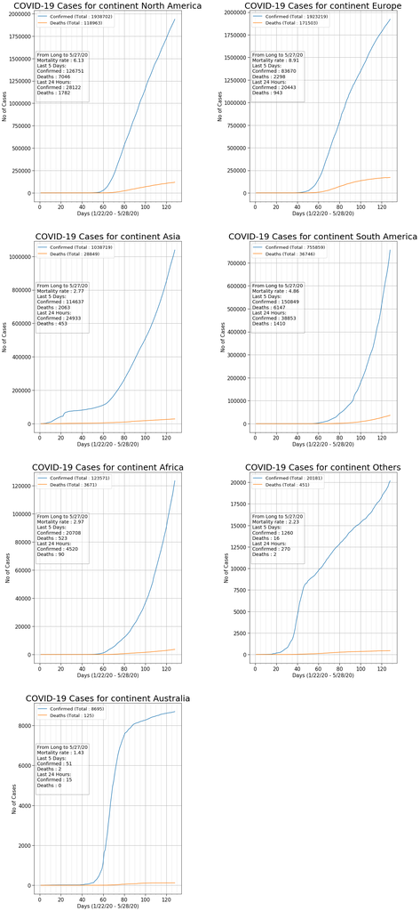

```python
df_continents= df_confirmed.groupby(["continent"]).sum()
continents = df_continents.sort_values(df_continents.columns[-1],ascending = False).index

cols =2
rows = int(np.ceil(continents.shape[0]/cols))
f = plt.figure(figsize=(20,10*rows))
for i,continent in enumerate(continents):
    visualize_covid_cases(df_confirmed, df_deaths,continent = continent,figure = [f,rows,cols, i+1])
plt.savefig('Continent wise spread.png')
plt.show()
```

# Trend Comparison of Sauid Arabia and top 10 countries

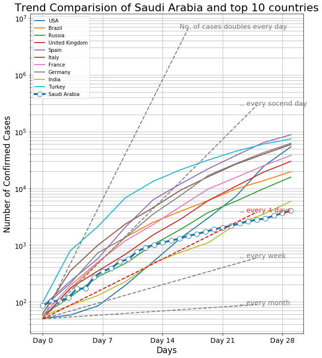

```python
temp = df_confirmed.groupby('country').sum().drop(["Lat","Long"],axis =1).sort_values(df_confirmed.columns[-1], ascending= False)

threshold = 50
f = plt.figure(figsize=(10,12))
ax = f.add_subplot(111)
for i,country in enumerate(temp.index):
    if i >= 10:
        if country != "Saudi Arabia":
            continue
    x = 30
    t = temp.loc[temp.index== country].values[0]
    t = t[t>threshold][:x]

    date = np.arange(0,len(t[:x]))
    xnew = np.linspace(date.min(), date.max(), 10)
    spl = make_interp_spline(date, t, k=1)
    power_smooth = spl(xnew)
    if country != "Saudi Arabia":
        plt.plot(xnew,power_smooth,label = country,linewidth =2)
    else:
        marker_style = dict(linewidth=4, linestyle='-', marker='o',markersize=10, markerfacecolor='#ffffff')
        plt.plot(date,t,"-.",label = country,**marker_style)

plt.tick_params(labelsize = 14)
plt.xticks(np.arange(0,30,7),[ "Day "+str(i) for i in range(30)][::7])

x = np.arange(0,18)
y = 2**(x+np.log2(threshold))
plt.plot(x,y,"--",linewidth =2,color = "gray")
plt.annotate("No. of cases doubles every day",(x[-2],y[-1]),xycoords="data",fontsize=14,alpha = 0.5)

x = np.arange(0,26)
y = 2**(x/2+np.log2(threshold))
plt.plot(x,y,"--",linewidth =2,color = "gray")
plt.annotate(".. every socend day",(x[-3],y[-1]),xycoords="data",fontsize=14,alpha = 0.5)

x = np.arange(0,26)
y = 2**(x/7+np.log2(threshold))
plt.plot(x,y,"--",linewidth =2,color = "gray")
plt.annotate(".. every week",(x[-3],y[-1]),xycoords="data",fontsize=14,alpha = 0.5)

x = np.arange(0,26)
y = 2**(x/30+np.log2(threshold))
plt.plot(x,y,"--",linewidth =2,color = "gray")
plt.annotate(".. every month",(x[-3],y[-1]),xycoords="data",fontsize=14,alpha = 0.5)


x = np.arange(0,26)
y = 2**(x/4+np.log2(threshold))
plt.plot(x,y,"--",linewidth =2,color = "Red")
plt.annotate(".. every 4 days",(x[-3],y[-1]),color="Red",xycoords="data",fontsize=14,alpha = 0.8)


plt.xlabel("Days",fontsize=17)
plt.ylabel("Number of Confirmed Cases",fontsize=17)
plt.title("Trend Comparision of Saudi Arabia and top 10 countries",fontsize=22)
plt.legend(loc = "upper left")
plt.yscale("log")
plt.grid(which="both")
plt.savefig('Trend Comparision of Saudi Arabia and top 10 countries.png')
plt.show()
```

### Top ten countries with confirmed cases

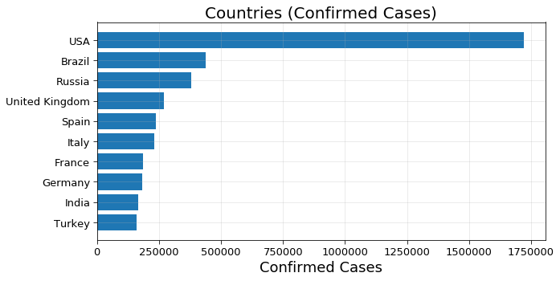

```python
f = plt.figure(figsize=(10,5))
f.add_subplot(111)

plt.barh(df_countries_cases.sort_values('Confirmed Cases')["Confirmed Cases"].index[-10:],df_countries_cases.sort_values('Confirmed Cases')["Confirmed Cases"].values[-10:],)
plt.tick_params(size=5,labelsize = 13)
plt.xlabel("Confirmed Cases",fontsize=18)
plt.title("Countries (Confirmed Cases)",fontsize=20)
plt.grid(alpha=0.3)
```

# Top 10 countires with deaths cases

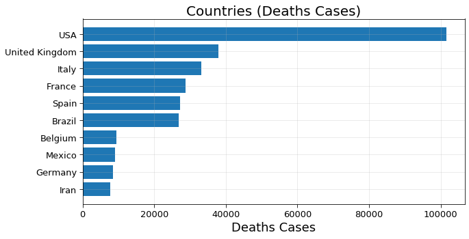

```python
f = plt.figure(figsize=(10,5))
f.add_subplot(111)

plt.barh(df_countries_cases.sort_values('Deaths Reported')["Deaths Reported"].index[-10:],df_countries_cases.sort_values('Deaths Reported')["Deaths Reported"].values[-10:])
plt.tick_params(size=5,labelsize = 13)
plt.xlabel("Deaths Cases",fontsize=18)
plt.title("Countries (Deaths Cases)",fontsize=20)
plt.grid(alpha=0.3)
```

# Mortality Rate Variation Over Period of Time

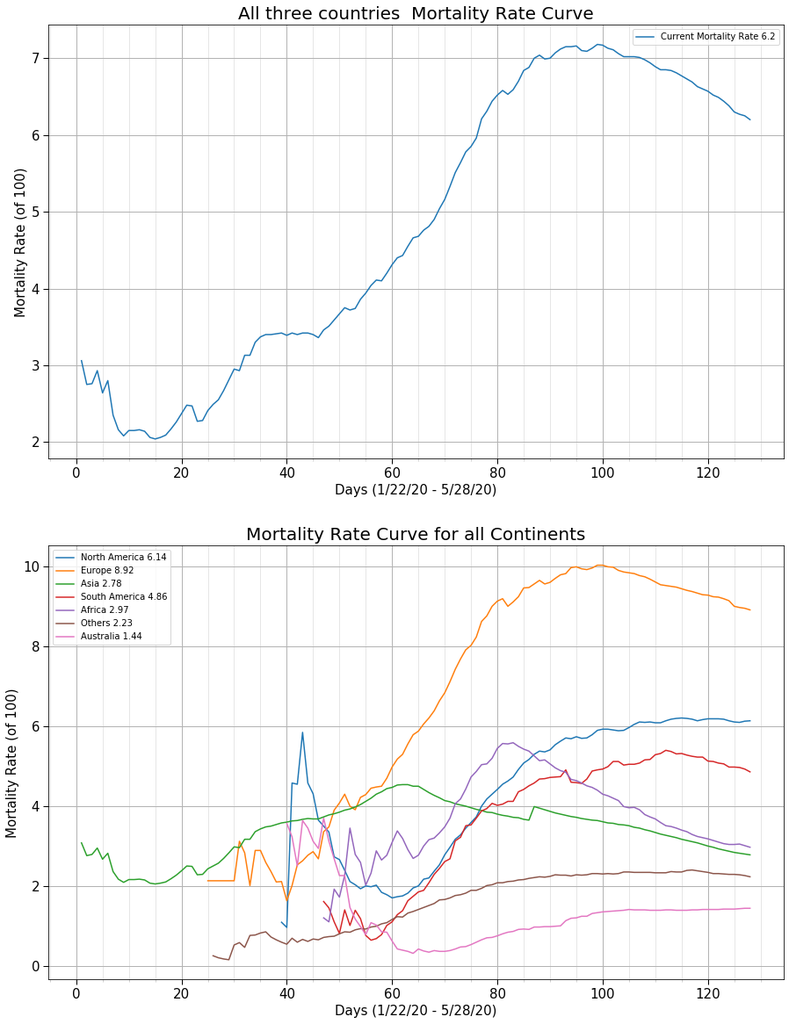

```python
df_continents= df_confirmed.groupby(["continent"]).sum()
continents = df_continents.sort_values(df_continents.columns[-1],ascending = False).index
continents = ["All"]+list(continents)

cols =1
rows = 2
axis_label = ["Days ("+df_confirmed.columns[5]+" - "+df_confirmed.columns[-1]+")","Mortality Rate (of 100)"]

f = plt.figure(figsize=(15,10*rows))


ax = f.add_subplot(211)
mortality_rate = get_mortality_rate(df_confirmed,df_deaths,continent=continents[0])
plt.plot(np.arange(1,mortality_rate.shape[0]+1),mortality_rate,label = "Current Mortality Rate "+str(mortality_rate[-1]))

plt_title = "All three countries  Mortality Rate Curve"
plot_params(ax,axis_label,plt_title)
l = plt.legend(loc= "best")



ax = f.add_subplot(212)
for i, continent in enumerate(continents[1:]):
    mortality_rate = get_mortality_rate(df_confirmed,df_deaths,continent=continent)
    plt.plot(np.arange(1+mortality_rate[mortality_rate == 0].shape[0],mortality_rate[mortality_rate == 0].shape[0]+mortality_rate[mortality_rate > 0].shape[0]+1),mortality_rate[mortality_rate > 0],label = continents[i+1]+" "+str(mortality_rate[-1]))

plt_title = "Mortality Rate Curve for all Continents"
plot_params(ax,axis_label,plt_title)

l = plt.legend(loc= "best")

plt.savefig('Mortality rate.png')
plt.show()
```

# Saudi Arabia Vs Rest of the world confirmed cases

```python
df_confirmed_report = df_confirmed.copy()
df_confirmed_report.loc[df_confirmed_report['country'] != "Saudi Arabia","country"] = "Rest of World"
df_confirmed_report = df_confirmed_report.groupby("country").sum().drop(["Lat","Long"],axis =1)
df_confirmed_report.loc["Total"] = df_confirmed_report.sum()
df_confirmed_newcases = df_confirmed_report.groupby(level =0).diff(axis =1)
df_confirmed_newcases=df_confirmed_newcases.drop(columns=['1/22/20'])
df_confirmed_newcases
```

| country | 1/23/20 | 1/24/20 | 1/25/20 | 1/26/20 | 1/27/20 | 1/28/20 | 1/29/20 | 1/30/20 | 1/31/20 | 2/1/20 | ... | 5/19/20 | 5/20/20 | 5/21/20 | 5/22/20 | 5/23/20 | 5/24/20 | 5/25/20 | 5/26/20 | 5/27/20 | 5/28/20 |
| --- | --- | --- | --- | --- | --- | --- | --- | --- | --- | --- | --- | --- | --- | --- | --- | --- | --- | --- | --- | --- | --- |
| Rest of World | 99.0 | 287.0 | 493.0 | 684.0 | 809.0 | 2651.0 | 588.0 | 2068.0 | 1693.0 | 2111.0 | ... | 93040.0 | 96289.0 | 103420.0 | 106090.0 | 97422.0 | 94194.0 | 85213.0 | 92634.0 | 100349.0 | 115512.0 |
| Saudi Arabia | 0.0 | 0.0 | 0.0 | 0.0 | 0.0 | 0.0 | 0.0 | 0.0 | 0.0 | 0.0 | ... | 2509.0 | 2691.0 | 2532.0 | 2642.0 | 2442.0 | 2399.0 | 2235.0 | 1931.0 | 1815.0 | 1644.0 |
| Total | 99.0 | 287.0 | 493.0 | 684.0 | 809.0 | 2651.0 | 588.0 | 2068.0 | 1693.0 | 2111.0 | ... | 95549.0 | 98980.0 | 105952.0 | 108732.0 | 99864.0 | 96593.0 | 87448.0 | 94565.0 | 102164.0 | 117156.0 |

3 rows × 127 columns

# Saving confirm cases of Saudi Arabia in new df

```python
df_confirmed_cases_Saudi_Arabia=df_confirmed_newcases
```

# Saudi Arabia Vs Rest of the world Deaths

```python
df_deaths_report = df_deaths.copy()
df_deaths_report.loc[df_deaths_report['country'] != "Saudi Arabia","country"] = "Rest of World"
df_deaths_report = df_deaths_report.groupby("country").sum().drop(["Lat","Long"],axis =1)
df_deaths_report.loc["Total"] = df_deaths_report.sum()
df_deaths_newcases = df_deaths_report.groupby(level =0).diff(axis =1)
df_deaths_newcases=df_deaths_newcases.drop(columns=['1/22/20'])
df_deaths_newcases
```

| country | 1/23/20 | 1/24/20 | 1/25/20 | 1/26/20 | 1/27/20 | 1/28/20 | 1/29/20 | 1/30/20 | 1/31/20 | 2/1/20 | ... | 5/19/20 | 5/20/20 | 5/21/20 | 5/22/20 | 5/23/20 | 5/24/20 | 5/25/20 | 5/26/20 | 5/27/20 | 5/28/20 |
| --- | --- | --- | --- | --- | --- | --- | --- | --- | --- | --- | --- | --- | --- | --- | --- | --- | --- | --- | --- | --- | --- |
| Rest of World | 1.0 | 8.0 | 16.0 | 14.0 | 26.0 | 49.0 | 2.0 | 38.0 | 42.0 | 46.0 | ... | 4795.0 | 4820.0 | 4797.0 | 5296.0 | 3965.0 | 2834.0 | 1164.0 | 4209.0 | 5162.0 | 4664.0 |
| Saudi Arabia | 0.0 | 0.0 | 0.0 | 0.0 | 0.0 | 0.0 | 0.0 | 0.0 | 0.0 | 0.0 | ... | 9.0 | 10.0 | 12.0 | 13.0 | 15.0 | 11.0 | 9.0 | 12.0 | 14.0 | 16.0 |
| Total | 1.0 | 8.0 | 16.0 | 14.0 | 26.0 | 49.0 | 2.0 | 38.0 | 42.0 | 46.0 | ... | 4804.0 | 4830.0 | 4809.0 | 5309.0 | 3980.0 | 2845.0 | 1173.0 | 4221.0 | 5176.0 | 4680.0 |

3 rows × 127 columns

# Saving Deaths of Saudi Arabia in new df

```python
df_deaths_cases_Saudi_Arabia=df_deaths_newcases
```

```python
pd.DataFrame([df_confirmed_report.iloc[:,-1],df_deaths_report.iloc[:,-1]],["Confirmed","Deaths"]).transpose()
```

| country | Confirmed | Deaths |
| --- | --- | --- |
| Rest of World | 5728761 | 359867 |
| Saudi Arabia | 80185 | 441 |
| Total | 5808946 | 360308 |

# Saudi Arabia confirm and deaths cases

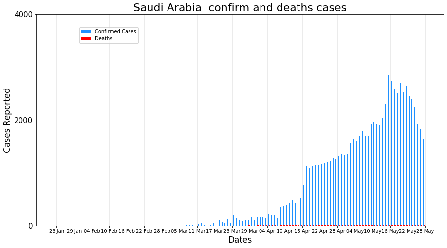

```python
f = plt.figure(figsize=(15,8))
ax = f.add_subplot(111)

ax.bar(np.arange(len(df_confirmed_newcases[df_confirmed_newcases.index == "Saudi Arabia"].columns)),df_confirmed_newcases[df_confirmed_newcases.index == "Saudi Arabia"].values[0], label = "Confirmed Cases",color='dodgerblue',width = 0.33)
ax.bar(0.33+np.arange(len(df_deaths_newcases[df_deaths_newcases.index == "Saudi Arabia"].columns)),df_deaths_newcases[df_deaths_newcases.index == "Saudi Arabia"].values[0], label = "Deaths",color='red',width = 0.5)

ax.set_xlabel("Dates",fontsize=17)
ax.set_ylabel("Cases Reported",fontsize =17)

ax.tick_params(labelsize=15)
ax.set_xticks(np.arange(0.5, len(df_confirmed_newcases.columns), 6))
ax.set_xticklabels([datetime.strptime(date,'%m/%d/%y').strftime("%d %b") for date in df_confirmed_newcases.columns][::6],fontsize=10)
ax.set_yticks(np.arange(0, df_confirmed_newcases.loc["Saudi Arabia"].max()+2000, 2000))
ax.legend(loc = "upper left", bbox_to_anchor=(0.1,0.95))
plt.title("Saudi Arabia  confirm and deaths cases",fontsize = 22)
plt.grid(alpha = 0.3)
plt.savefig('Saudi Arabia confirm and deaths cases.png')
plt.show()
```

# Confirm and Deaths cases wihtout Saudi Arabia

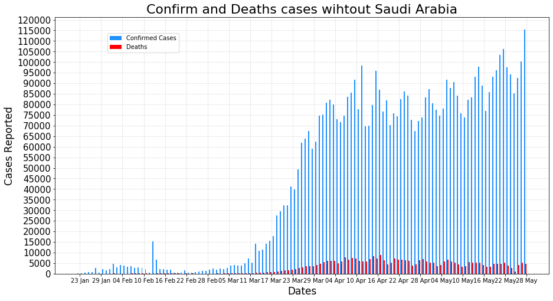

```python
f = plt.figure(figsize=(15,8))
ax = f.add_subplot(111)
ax.bar(np.arange(len(df_confirmed_newcases[df_confirmed_newcases.index == "Rest of World"].columns)),df_confirmed_newcases[df_confirmed_newcases.index == "Rest of World"].values[0], label = "Confirmed Cases",color='dodgerblue',width = 0.33)
ax.bar(0.33+np.arange(len(df_deaths_newcases[df_deaths_newcases.index == "Rest of World"].columns)),df_deaths_newcases[df_deaths_newcases.index == "Rest of World"].values[0], label = "Deaths",color='red',width = 0.33)
ax.set_xlabel("Dates",fontsize=17)
ax.set_ylabel("Cases Reported",fontsize =17)

ax.tick_params(labelsize=15)
ax.set_xticks(np.arange(0.5, len(df_confirmed_newcases.columns), 6))
ax.set_xticklabels([datetime.strptime(date,'%m/%d/%y').strftime("%d %b") for date in df_confirmed_newcases.columns][::6],fontsize=10)
ax.set_yticks(np.arange(0, df_confirmed_newcases.loc["Rest of World"].max()+5000, 5000))
ax.legend(loc = "upper left", bbox_to_anchor=(0.1,0.95))
plt.title("Confirm and Deaths cases wihtout Saudi Arabia",fontsize = 22)
plt.grid(alpha = 0.3)
plt.savefig('Confirm and Deaths wihtout Saudi Arabia.png')
plt.show()
```

# Saudi Arabia and Rest of the world Confrim cases and Deaths

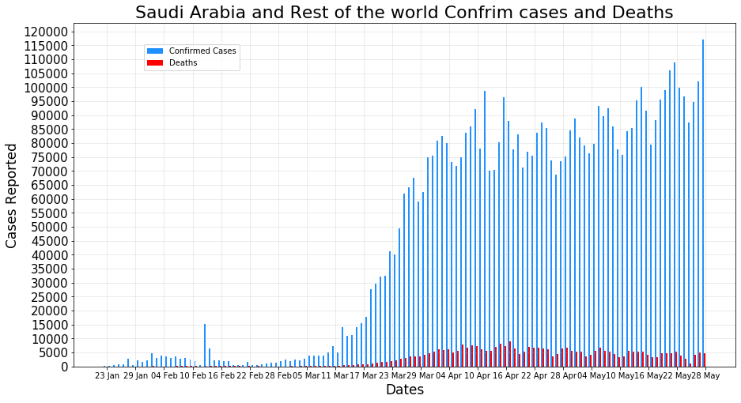

```python
f = plt.figure(figsize=(15,8))
ax = f.add_subplot(111)

ax.bar(np.arange(len(df_confirmed_newcases[df_confirmed_newcases.index == "Total"].columns)),df_confirmed_newcases[df_confirmed_newcases.index == "Total"].values[0], label = "Confirmed Cases",color='dodgerblue',width = 0.33)
ax.bar(0.33+np.arange(len(df_deaths_newcases[df_deaths_newcases.index == "Total"].columns)),df_deaths_newcases[df_deaths_newcases.index == "Total"].values[0], label = "Deaths",color='red',width = 0.33)
ax.set_xlabel("Dates",fontsize=17)
ax.set_ylabel("Cases Reported",fontsize =17)

ax.tick_params(labelsize=15)
ax.set_xticks(np.arange(0.5, len(df_confirmed_newcases.columns), 6))
ax.set_xticklabels([datetime.strptime(date,'%m/%d/%y').strftime("%d %b") for date in df_confirmed_newcases.columns][::6],fontsize=10)
ax.set_yticks(np.arange(0, df_confirmed_newcases.loc["Total"].max()+5000, 5000))
ax.legend(loc = "upper left", bbox_to_anchor=(0.1,0.95))
plt.title("Saudi Arabia and Rest of the world Confrim cases and Deaths",fontsize = 22)
plt.grid(alpha = 0.3)
plt.savefig('Saudi Arabia and Rest of the world Confrim cases and Deaths.png')
plt.show()
```

# -----------------------------------------------------------------------------------------------------

# -----------------------------------------------------------------------------------------------------

# -----------------------------------------------------------------------------------------------------

# -----------------------------------------------------------------------------------------------------

# -----------------------------------------------------------------------------------------------------

# Saudi Arabia Confirm Cases Predictions

# -----------------------------------------------------------------------------------------------------

# Preparing Confirm cases data for Training and predictions

```python
confirm=df_confirmed_cases_Saudi_Arabia
```

```python
confirm
```

| country | 1/23/20 | 1/24/20 | 1/25/20 | 1/26/20 | 1/27/20 | 1/28/20 | 1/29/20 | 1/30/20 | 1/31/20 | 2/1/20 | ... | 5/19/20 | 5/20/20 | 5/21/20 | 5/22/20 | 5/23/20 | 5/24/20 | 5/25/20 | 5/26/20 | 5/27/20 | 5/28/20 |
| --- | --- | --- | --- | --- | --- | --- | --- | --- | --- | --- | --- | --- | --- | --- | --- | --- | --- | --- | --- | --- | --- |
| Rest of World | 99.0 | 287.0 | 493.0 | 684.0 | 809.0 | 2651.0 | 588.0 | 2068.0 | 1693.0 | 2111.0 | ... | 93040.0 | 96289.0 | 103420.0 | 106090.0 | 97422.0 | 94194.0 | 85213.0 | 92634.0 | 100349.0 | 115512.0 |
| Saudi Arabia | 0.0 | 0.0 | 0.0 | 0.0 | 0.0 | 0.0 | 0.0 | 0.0 | 0.0 | 0.0 | ... | 2509.0 | 2691.0 | 2532.0 | 2642.0 | 2442.0 | 2399.0 | 2235.0 | 1931.0 | 1815.0 | 1644.0 |
| Total | 99.0 | 287.0 | 493.0 | 684.0 | 809.0 | 2651.0 | 588.0 | 2068.0 | 1693.0 | 2111.0 | ... | 95549.0 | 98980.0 | 105952.0 | 108732.0 | 99864.0 | 96593.0 | 87448.0 | 94565.0 | 102164.0 | 117156.0 |

3 rows × 127 columns

```python
confirm=confirm.T
```

```python
confirm['Date']=confirm.index
```

```python
confirm=confirm[['Date', 'Saudi Arabia']]
```

```python
confirm_cases=pd.DataFrame()
```

```python
confirm_cases['Date']=confirm['Date']
confirm_cases['Saudi Arabia cases']=confirm['Saudi Arabia']
```

```python
confirm_cases=confirm_cases.reset_index()
confirm_cases=confirm_cases.drop(columns=['index'])
```

# If we look at the first 55 days so there are no cases in Saudi Arabia but few in some day between but in index 39 to 55 increasing slowly

```python
confirm_cases.head(55)
```

|  | Date | Saudi Arabia cases |
| --- | --- | --- |
| 0 | 1/23/20 | 0.0 |
| 1 | 1/24/20 | 0.0 |
| 2 | 1/25/20 | 0.0 |
| 3 | 1/26/20 | 0.0 |
| 4 | 1/27/20 | 0.0 |
| 5 | 1/28/20 | 0.0 |
| 6 | 1/29/20 | 0.0 |
| 7 | 1/30/20 | 0.0 |
| 8 | 1/31/20 | 0.0 |
| 9 | 2/1/20 | 0.0 |
| 10 | 2/2/20 | 0.0 |
| 11 | 2/3/20 | 0.0 |
| 12 | 2/4/20 | 0.0 |
| 13 | 2/5/20 | 0.0 |
| 14 | 2/6/20 | 0.0 |
| 15 | 2/7/20 | 0.0 |
| 16 | 2/8/20 | 0.0 |
| 17 | 2/9/20 | 0.0 |
| 18 | 2/10/20 | 0.0 |
| 19 | 2/11/20 | 0.0 |
| 20 | 2/12/20 | 0.0 |
| 21 | 2/13/20 | 0.0 |
| 22 | 2/14/20 | 0.0 |
| 23 | 2/15/20 | 0.0 |
| 24 | 2/16/20 | 0.0 |
| 25 | 2/17/20 | 0.0 |
| 26 | 2/18/20 | 0.0 |
| 27 | 2/19/20 | 0.0 |
| 28 | 2/20/20 | 0.0 |
| 29 | 2/21/20 | 0.0 |
| 30 | 2/22/20 | 0.0 |
| 31 | 2/23/20 | 0.0 |
| 32 | 2/24/20 | 0.0 |
| 33 | 2/25/20 | 0.0 |
| 34 | 2/26/20 | 0.0 |
| 35 | 2/27/20 | 0.0 |
| 36 | 2/28/20 | 0.0 |
| 37 | 2/29/20 | 0.0 |
| 38 | 3/1/20 | 0.0 |
| 39 | 3/2/20 | 1.0 |
| 40 | 3/3/20 | 0.0 |
| 41 | 3/4/20 | 0.0 |
| 42 | 3/5/20 | 4.0 |
| 43 | 3/6/20 | 0.0 |
| 44 | 3/7/20 | 0.0 |
| 45 | 3/8/20 | 6.0 |
| 46 | 3/9/20 | 4.0 |
| 47 | 3/10/20 | 5.0 |
| 48 | 3/11/20 | 1.0 |
| 49 | 3/12/20 | 24.0 |
| 50 | 3/13/20 | 41.0 |
| 51 | 3/14/20 | 17.0 |
| 52 | 3/15/20 | 0.0 |
| 53 | 3/16/20 | 15.0 |
| 54 | 3/17/20 | 53.0 |

# So going to Ignore fisrt above days data and goin to use the next

```python
confirm_cases=confirm_cases[56:]
confirm_cases
```

|  | Date | Saudi Arabia cases |
| --- | --- | --- |
| 56 | 3/19/20 | 103.0 |
| 57 | 3/20/20 | 70.0 |
| 58 | 3/21/20 | 48.0 |
| 59 | 3/22/20 | 119.0 |
| 60 | 3/23/20 | 51.0 |
| ... | ... | ... |
| 122 | 5/24/20 | 2399.0 |
| 123 | 5/25/20 | 2235.0 |
| 124 | 5/26/20 | 1931.0 |
| 125 | 5/27/20 | 1815.0 |
| 126 | 5/28/20 | 1644.0 |

71 rows × 2 columns

# Date settings and Saudi Arabia preparation

```python
confirm_cases['times'] = pd.to_datetime(confirm_cases['Date'])
confirm_cases.set_index('times', inplace=True)
confirm_cases.sort_index(ascending=True, inplace=True)
tar='Saudi Arabia Cases Predictions'
confirm_cases.rename(columns={'Saudi Arabia cases':tar}, inplace=True)
confirm_cases=confirm_cases[[tar]]
```

# Spliting date into month, year and Day of month

```python
def create_features(data, label=None):
    data['date'] = data.index
    data['month'] = data['date'].dt.month
    data['year'] = data['date'].dt.year
    data['dayofmonth'] = data['date'].dt.day
    X = data[['month','year','dayofmonth']]
    if label:
        y = data[label]
        return X, y
    return X
```

# Data for training input and prediction output

```python
test=confirm_cases.copy()
X= create_features(test)
y=confirm_cases
```

# ------------------------------------------------------------------------------------------------------

# ----------------Machine Learning Algorithm and Evaluation-----------------------

# ------------------------------------------------------------------------------------------------------

# PLS Algorithm

```python
from sklearn.cross_decomposition import PLSRegression
pls = PLSRegression()
```

# Cross validation

```python
from sklearn.model_selection import KFold
from sklearn.metrics import mean_squared_error
from sklearn.metrics import mean_absolute_error

x=np.array(X)
y=np.array(y)
y=y.ravel()
kf = KFold(n_splits=5)
outcomes2 = []
ClassR=0
ConM=0
fold = 0
i=0
conf_matrix_list_of_arrays = []
for train_index, test_index in kf.split(x,y):
    i=i+1
    print('\n')
    print("Cross validation",i)
    fold += 1
    Xtrain, Xtest = x[train_index], x[test_index]
    ytrain, y_test = y[train_index], y[test_index]
    pls.fit(Xtrain, ytrain)
    y_pred = pls.predict(Xtest)
    MAE=mean_absolute_error(y_test,y_pred)
    print('Mean Absolute error: ', MAE)
    mse=mean_squared_error(y_test,y_pred)
    rmse = math.sqrt(mse)
    print('Root mean squared error: ', rmse)
```

```
Cross validation 1
Mean Absolute error:  344.73707352672886
Root mean squared error:  389.63551384336705


Cross validation 2
Mean Absolute error:  386.7197873073992
Root mean squared error:  389.7704420195175


Cross validation 3
Mean Absolute error:  80.22933068306236
Root mean squared error:  96.47282814238594


Cross validation 4
Mean Absolute error:  79.28077195235635
Root mean squared error:  95.76549198441855


Cross validation 5
Mean Absolute error:  443.1200366369449
Root mean squared error:  517.726800847102
```